# 21MIA1025 - Abhineswari M - CSE4076 - Lab Assignment 02

# 1. Setup and basic extraction

Objective: Install the necessary tools and libraries, and extract frame information from a video . Steps:

1. Install ffmpeg and ffmpeg-python:

```python
!pip install ffmpeg-python
```

```python
import ffmpeg

# Path to the input video file
input_video = 'football.mp4'
print(input_video)
```

```
football.mp4
```

2. Extract Frame Information:

o Extract frame information from a sample video.

```python
import subprocess
import json

ffprobe_executable = r'C:\Users\Abhineswari Madan\Downloads\ffmpeg-build\ffmpeg-full_build\bin\ffprobe.exe'

# Run ffprobe to get video information
result = subprocess.run([ffprobe_executable, '-v', 'error', '-show_entries', 'stream=codec_name,width,height,r_frame_rate,nb_frames,duration', '-of', 'json', input_video],
                        stdout=subprocess.PIPE, stderr=subprocess.PIPE, text=True)

# Parse the JSON output
probe = json.loads(result.stdout)

# Print the entire JSON output to inspect its structure
print(json.dumps(probe, indent=4))

# Extract and print information about the video streams
for stream in probe.get('streams', []):
    # Determine if the stream is video by checking for video-specific keys
    if 'width' in stream and 'height' in stream:
        print(f"Codec: {stream.get('codec_name', 'N/A')}")
        print(f"Width: {stream.get('width', 'N/A')}")
        print(f"Height: {stream.get('height', 'N/A')}")
        print(f"Frame rate: {stream.get('r_frame_rate', 'N/A')}")
        print(f"Number of frames: {stream.get('nb_frames', 'N/A')}")
        print(f"Duration (seconds): {stream.get('duration', 'N/A')}")
        print("-------")
```

```
{
    "programs": [],
    "stream_groups": [],
    "streams": [
        {
            "codec_name": "h264",
            "width": 736,
            "height": 480,
            "r_frame_rate": "60000/1001",
            "duration": "14.601667",
            "nb_frames": "591"
        },
        {
            "codec_name": "aac",
            "r_frame_rate": "0/0",
            "duration": "14.651791",
            "nb_frames": "631"
        }
    ]
}
Codec: h264
Width: 736
Height: 480
Frame rate: 60000/1001
Number of frames: 591
Duration (seconds): 14.601667
-------
```

```python
# Output pattern for frame images
output_pattern = 'frame_%04d.png'

# Path to the ffmpeg executable
ffmpeg_executable = r'C:\Users\Abhineswari Madan\Downloads\ffmpeg-build\ffmpeg-full_build\bin\ffmpeg.exe'

# Run ffmpeg command to extract frames
subprocess.run([
    ffmpeg_executable,  # Use the full path to ffmpeg
    '-i', input_video,
    '-vf', 'fps=1',  # Adjust frame rate as needed
    output_pattern
], check=True)

print(f"Frames extracted and saved as {output_pattern}")
```

```
Frames extracted and saved as frame_%04d.png
```

```python
output_pattern = r'C:\Users\Abhineswari Madan\Videos\frames\frame_%04d.png'
print(output_pattern)
```

```
C:\Users\Abhineswari Madan\Videos\frames\frame_%04d.png
```

# 2. Frame Type Analysis

Analyze the extracted frame information to understand the distribution of I,P and B frames in a video.

Steps:

1. Modify the Script:

o Count the number of I, P, and B frames. o Calculate the percentage of each frame type in the video.

```python
import subprocess
import json
import matplotlib.pyplot as plt

# Paths to executables
ffprobe_executable = r'C:\Users\Abhineswari Madan\Downloads\ffmpeg-build\ffmpeg-full_build\bin\ffprobe.exe'
ffmpeg_executable = r'C:\Users\Abhineswari Madan\Downloads\ffmpeg-build\ffmpeg-full_build\bin\ffmpeg.exe'

# Path to the input video file
input_video = 'football.mp4'

# Run ffprobe to get frame type information
result = subprocess.run([ffprobe_executable, '-v', 'error', '-select_streams', 'v:0', '-show_entries', 'frame=pict_type', '-of', 'json', input_video],
                        stdout=subprocess.PIPE, stderr=subprocess.PIPE, text=True)

# Parse the JSON output
frames_info = json.loads(result.stdout)
frame_types = [frame['pict_type'] for frame in frames_info.get('frames', [])]

# Count occurrences of each frame type
frame_count = {'I': 0, 'P': 0, 'B': 0}
for frame_type in frame_types:
    if frame_type in frame_count:
        frame_count[frame_type] += 1

# Calculate total frames and percentages
total_frames = sum(frame_count.values())
frame_percentages = {ft: (count / total_frames) * 100 for ft, count in frame_count.items()}

# Print frame counts and percentages
print("Frame Counts:")
for frame_type, count in frame_count.items():
    print(f"{frame_type} frames: {count} ({frame_percentages[frame_type]:.2f}%)")
```

```
Frame Counts:
I frames: 15 (2.54%)
P frames: 576 (97.46%)
B frames: 0 (0.00%)
```

2. Analyze Frame Distribution:

o Plot the distribution of frame types using a library like matplotlib. o Plot a pie chart or bar graph showing the distribution of frame types using matplotlib.

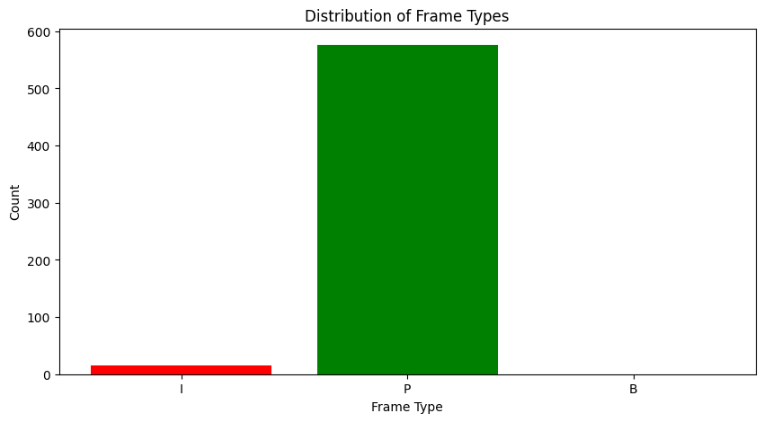

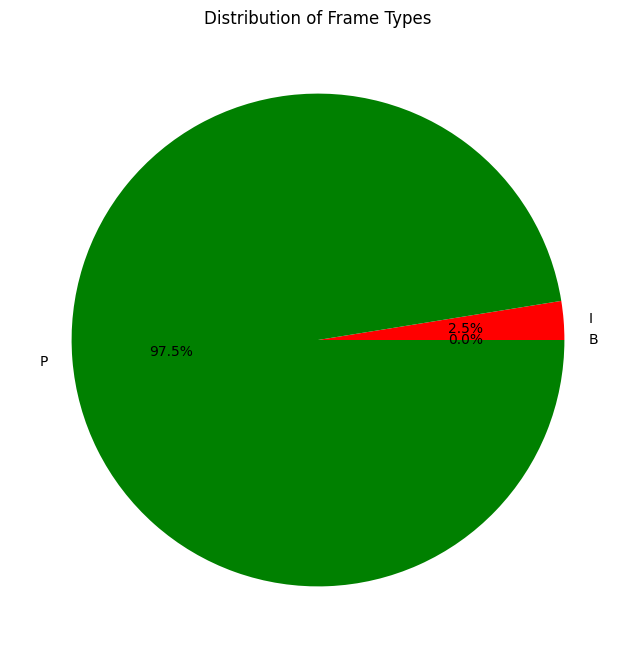

```python
# Plot distribution of frame types
frame_labels = list(frame_count.keys())
frame_values = list(frame_count.values())

# Bar chart
plt.figure(figsize=(10, 5))
plt.bar(frame_labels, frame_values, color=['red', 'green', 'blue'])
plt.xlabel('Frame Type')
plt.ylabel('Count')
plt.title('Distribution of Frame Types')
plt.show()

# Pie chart
plt.figure(figsize=(8, 8))
plt.pie(frame_values, labels=frame_labels, autopct='%1.1f%%', colors=['red', 'green', 'blue'])
plt.title('Distribution of Frame Types')
plt.show()
```